# Lecture 2 – Linear Regression and Extensions

2016-04-26

## Linear Regression

We start with a linear regression model:\[ y_i = x_i' \beta + \varepsilon_i, i=1, \ldots,n, \]where \(x_i\) is a p-dimensional vector of regressors for observation \(i\), \(\beta\) a p-dimensional coefficient vector, and \(\varepsilon_i\) iid error terms with \(\mathbb{E} [\varepsilon_i|x_i]= 0\).

The ordinary least squares (ols) estimator for \(\beta\) is defined as

\[ \hat{\beta} = \arg\min_{\beta \in \mathbb{R}^p} \sum_{i=1}^n (y_i - x_i' \beta)^2.\]

## Linear Regression

If the Gram matrix \(\sum_{i=1}^n x_i x_i'\) is of full rank, the ols estimate is given by

\[ \hat{\beta} = (\sum_{i=1}^n x_i x_i')^{-1} (\sum_{i=1}^n x_i y_i). \]

The residuals \(\hat{\varepsilon}_i\) are defined as\[ \hat{\varepsilon}_i = y_i - x_i'\hat{\beta}. \]For an observation \(x\) the *fitted* or *predicted* values are given by\[ \hat{y} = x'\hat{\beta}. \]

## Linear Regression

In matrix notation we can write

\[ Y=X \beta + \varepsilon \]

with \(Y=\begin{pmatrix} y_1 & \ldots & y_n \end{pmatrix}\), \(\varepsilon=\begin{pmatrix} \varepsilon_1 & \ldots & \varepsilon_n \end{pmatrix}\) and \(X\) is a \(n \times p\)-matrix with observation \(i\) forming the \(i\)th row of the matrix \(X\).

The ols estimate \(\hat{\beta}\) can then be written as

\[ \hat{\beta} = (X'X)^{-1}X'y.\]

## Linear Regression

Under homoscedastic errors, i.e. \(\mathbb{Var} \varepsilon_i=\sigma^2\), we have that

\[ \mathbb{Var}(\hat{\beta})= (X'X)^{-1} \sigma^2.\]

Asymptotically, the ols estimate is normal distributed:

\[ \hat{\beta} \sim N(\beta, (X'X)^{-1} \sigma^2).\]

This can be used for testing hypotheses and construction of confidence intervals.

## Linear Regression

\[ z_j=\frac{\hat{\beta_j}}{\hat{\sigma}^2 \sqrt{v_j}}\]where \(v_j\) is the \(j\)th diagonal element of \((X'X)^{-1}\).  
Under the null hypothesis \(\beta_j=0\) the *Z-score* / *t-statistic* \(z_j\) is \(t_{n-p-1}\)-distributed.

## Linear Regression

Remark: In the high-dimensional-setting, i.e. \(p >> n\) the Gram Matrix is rank deficient and the ols estimate is not uniquely defined and the variance of the parameter estimate is unbounded.

## Extensions

- Polynomial Regression
- Step Functions
- Basis Functions
- Regression Splines
- Smoothing Splines

## Extensions

### Remarks

- Although the linear regression model looks quite simple, it can be extended / modified to model complex relations.
- For the extensions we consider without loss of generality univariate regressions:

\[ y_i=\beta_0 + \beta_1 x_i + \varepsilon_i\]

## Extensions

### Polynomial Regression

To make the linear specification more flexible, we might include higher-order polynomials:

\[y_i = \beta_0 + \beta_1 x_i + \beta_2 x_i^2 + \ldots \beta_p x_i^p + \varepsilon_i\]

- Estimation by ols
- Quite flexible, but usually p=3 or p=4
- Higher order polynomials (p > 5) might lead to strange fits (overfitting), especially at the boundary.

## Extensions

### Polynomial Regression - Example

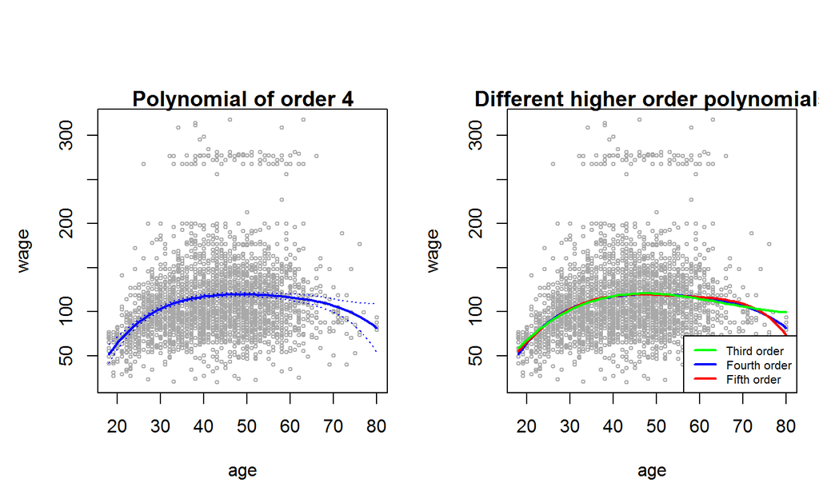

## Extensions

### Step Functions

- Definition: Step functions are functions which are constant on each part of a partition of the domain.
- Univariate Regression: choosing \(K\) cut points \(c_1, \ldots, c_K\) and defining new auxiliary variables:  
  \(C_0(x)= 1(x < c_1)\), \(C_1(x)=1(c_1 \leq x < c_2)\), \(\ldots\), \(C_K(x)=1(c_K \leq x)\)
- \(1(\cdot)\) is the so-called indicator function which is \(1\) is the condition is true and \(0\) otherwise.
- This gives us the following regression:\[ y_i = \beta_0 = \beta_1 *C_1(x_i) + \ldots + \beta_K *C_K(x_i) + \varepsilon_i \]

## Extensions | Step Functions

- Note: \(C_0(x) + \ldots + C_K(x) = 1\) and hence we drop \(C_0=(\cdot)\) to avoid multicollinearity.
- Interpretation \(\beta_0\)
- Example: wage regression

## Extensions

### Step Functions

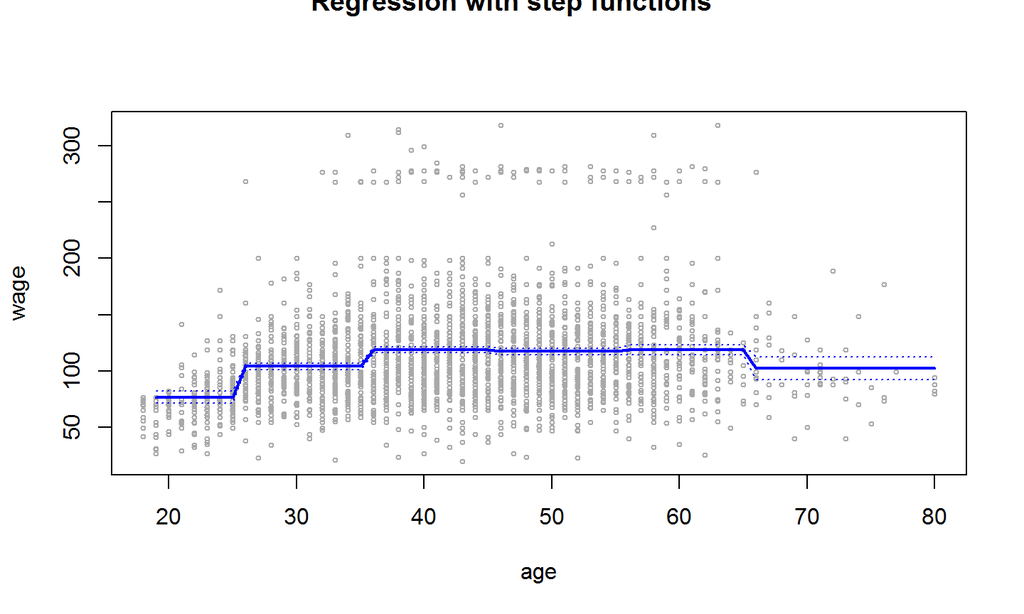

## Extension

### Basis Functions

- Idea: family of functions or transformations that can be applied to a variable: \(b_1(x), \ldots, b_K(x)\) (basis functions)
- Regression: \[y_i = \beta_0 + \beta_1 b_1(x_i) + \ldots + \beta_K b_K(x_i) + \varepsilon_i \]
- Examples
- Polynomial regression: \(b_j(x_i)=x^j_i\)
- Piecewise constant functions (step functions): \(b_j(x_i)=1(c_j \leq x_i < c_{j+1})\)
- Regressions splines (coming next)